# Week 5 – Data Visualization & EDA

Python Visualization · EDA Framework · The Semester Project

## Welcome to Week 5

**Three things today:**

1. **Your Visualization Toolkit** — Pandas, Seaborn, Matplotlib, and Bokeh, and when to reach for each
2. **EDA Framework** — how to think through an analysis, not just run code
3. **The Semester Project** — the scenario, deliverables, and Thursday’s lab

Today is about **orientation, not memorization**. The companion notebook has every example we see — plus the ones we skip.

## 📓 Follow Along in the Notebook

**Week 5 Lecture Notebook**

Open the companion notebook in Colab now. Everything we demo today is in there, runnable — along with cheat sheets for all four libraries and extra practice we won’t get to in class.

[figure not shown]

Open In Colab

## Questions from Week 4?

- Manipulating & cleaning DataFrames?
- Aggregating data with `groupby`?
- Joining datasets to bring in context?
- Anything from the quiz or lab?

Anything still fuzzy from last week — now is the time.

# Part 1: Your Visualization Toolkit

## How Quickly Can You Spot Insights?

What can you tell from this table?

| Week | Produce | Dairy | Frozen | Deli |
| --- | --- | --- | --- | --- |
| 1 | 11,500 | 12,100 | 7,320 | 4,100 |
| 2 | 12,800 | 11,400 | 7,180 | 4,080 |
| 3 | 12,200 | 10,800 | 1,780 | 4,120 |
| 4 | 13,900 | 10,100 | 7,410 | 4,090 |
| 5 | 13,400 | 9,800 | 7,260 | 4,110 |
| 6 | 15,100 | 9,200 | 7,350 | 4,085 |
| 7 | 14,800 | 8,700 | 7,420 | 4,115 |
| 8 | 16,400 | 8,100 | 7,190 | 4,095 |

## How Quickly Can You Spot Insights?

What can you tell from this plot?

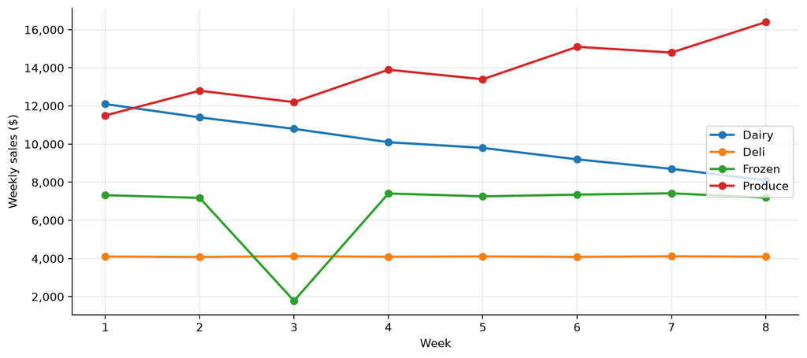

## Different Visualization Needs

**Scenario 1**

You just pulled the Complete Journey data and need to quickly check whether basket spend looks reasonable before writing any analysis code.

**Scenario 2**

You’re presenting weekly revenue trends to the VP of Marketing in a board meeting. The chart will appear in a formal slide deck.

**Scenario 3**

The promotions team wants a tool to interactively explore coupon redemption rates by store, product category, and week.

**Same data. Three very different jobs.** No single library is best at all three.

## Match the Tool to the Goal

We should match *how* we visualize to the goal we have in mind.

| Purpose | Tool | Why It Wins Here |
| --- | --- | --- |
| Quick EDA | **Pandas** `.plot()` | One line, straight off a DataFrame |
| Statistical comparison | **Seaborn** | Handles grouping, ordering, and stats for you |
| Polished reporting | **Matplotlib** | Total control over every element |
| Interactive exploration | **Bokeh** | Renders to the browser — zoom, hover, filter |

**Tip**

These are not four competitors. Pandas and Seaborn are both built **on top of** Matplotlib — so they stack.

# Pandas: Speed

## Pandas — When Speed Beats Polish

- Your **first reach** when you need a fast answer — minimal code, tied directly to DataFrames
- Call `.plot()` on any Series or DataFrame and pass `kind=`
- Built on Matplotlib, so anything you learn later still applies
- **Not** meant for final deliverables

**Tip**

If you can answer your question in one line, Pandas `.plot()` is the right tool. Rule of thumb: if you’re typing a third line of formatting, you may want to switch libraries.

## Pandas in One Line

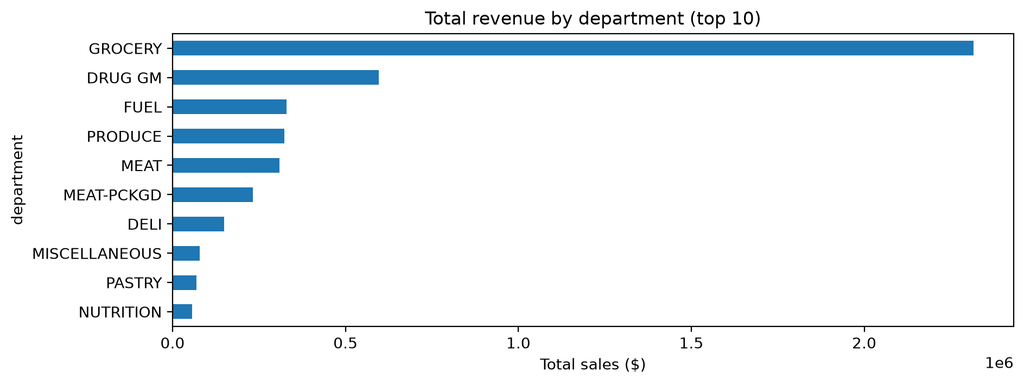

```python
category_totals.plot(
    kind='barh', x='department', y='sales_value',
    figsize=(10, 3.5), legend=False,
    title='Total revenue by department (top 10)', xlabel='Total sales ($)'
)
plt.show()
```

Swap `kind=` to change the chart: `'hist'`, `'box'`, `'line'`, `'bar'`, `'scatter'`, `'barh'`.

# Seaborn: Statistical Grouping

## Seaborn — When You’re Comparing Groups

- Built on Matplotlib — cleaner syntax for common **statistical** chart types
- Shines when you need **grouping, ordering, and distributions with shape**
- One function call handles what Matplotlib needs 10–15 lines to produce

| Pandas | Seaborn |
| --- | --- |
| `.plot(kind='hist')` — basic bin counts | `histplot()` — bins + KDE curve in one call |
| `.groupby().mean().plot.bar()` — manual aggregation | `boxplot()` / `barplot()` — handles stats automatically |
| No built-in group ordering | `order=` parameter on every chart |

Every Seaborn function follows one pattern: `sns.function(data=df, x=…, y=…, hue=…, order=…)`

## Seaborn in One Call

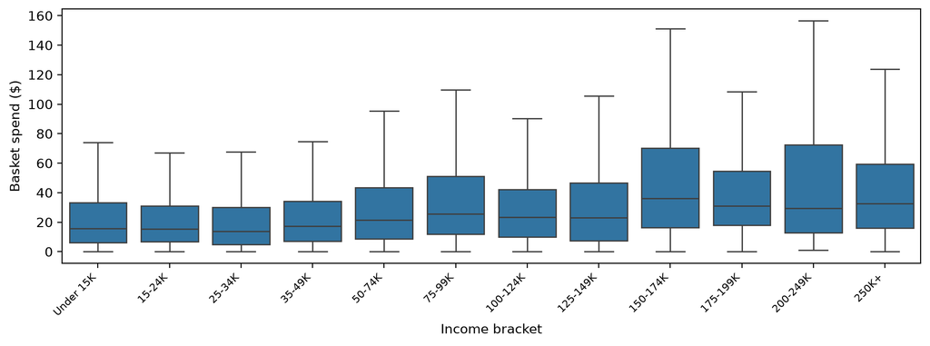

```python
fig, ax = plt.subplots(figsize=(10, 3.8))
sns.boxplot(
    data=basket_demo,
    x='income',
    y='basket_spend',
    order=income_order,   # explicit ordering — critical for income brackets
    ax=ax,
    showfliers=False
)
ax.set_xticklabels(ax.get_xticklabels(), rotation=45, ha='right', fontsize=8)
ax.set_xlabel('Income bracket')
ax.set_ylabel('Basket spend ($)')
plt.tight_layout()
plt.show()
```

# Matplotlib: Control

## Matplotlib — When the Chart Must Stand Alone

- The most widely used Python plotting library — and the **foundation** for Seaborn and Pandas
- **Full customization:** labels, annotations, tick formatting, styles, multi-panel layouts, export
- Because Pandas and Seaborn return Matplotlib objects, you can start fast and polish later

**Tip**

Use Matplotlib when the chart needs to stand on its own — in a report, a slide deck, or a published figure. **This is the library your project report will live on.**

## The Figure / Axes Hierarchy

Everything in Matplotlib is an object you can reference and modify:

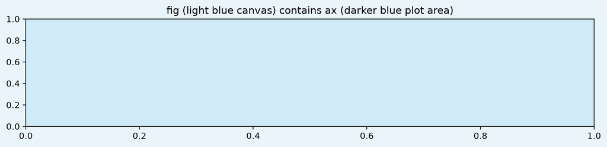

```python
fig, ax = plt.subplots(figsize=(10, 2.5))
# fig = the overall canvas
# ax  = the actual plot area (axes, ticks, lines, labels)
fig.set_facecolor('#eaf4fb')
ax.set_facecolor('#d0eaf8')
ax.set_title('fig (light blue canvas) contains ax (darker blue plot area)')
plt.tight_layout()
plt.show()
```

Once you have `fig` and `ax`, you control **everything** — including plots Seaborn or Pandas drew for you.

## Before: A Quick Pandas Plot

Fast, but it would not survive an executive meeting:

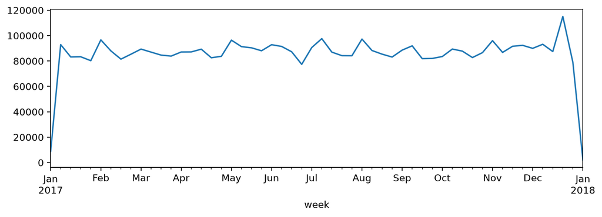

```python
weekly_sales.plot(kind='line', x='week', y='total_sales', figsize=(10, 3.0), legend=False)
plt.show()
```

## After: Executive-Ready Matplotlib

```python
fig, ax = plt.subplots(figsize=(10, 3.5))
ax.plot(weekly_sales['week'], weekly_sales['total_sales'], linewidth=2)

# --- readable formatting ---
ax.set_title('Weekly total sales — note holiday spike in late December', pad=10)
ax.set_xlabel('Week')
ax.yaxis.set_major_formatter(mtick.StrMethodFormatter('${x:,.0f}'))
ax.grid(True, alpha=0.3)
for spine in ['top', 'right']:
    ax.spines[spine].set_visible(False)

# --- annotate the insight ---
peak_idx  = weekly_sales['total_sales'].idxmax()
peak_week = weekly_sales.loc[peak_idx, 'week']
peak_val  = weekly_sales.loc[peak_idx, 'total_sales']
ax.annotate(
    f'Holiday spike\n${peak_val:,.0f}',
    xy=(peak_week, peak_val),
    xytext=(peak_week - pd.Timedelta(weeks=8), peak_val * 0.97),
    arrowprops=dict(arrowstyle='->', lw=1.2),
    fontsize=9
)
plt.tight_layout()
plt.show()
```

**Caution**

Matplotlib is powerful but verbose. There is a massive [example gallery](https://matplotlib.org/stable/gallery/index.html), and AI tools are very good at adapting Matplotlib code. The notebook walks this build step by step.

## After: Executive-Ready Matplotlib

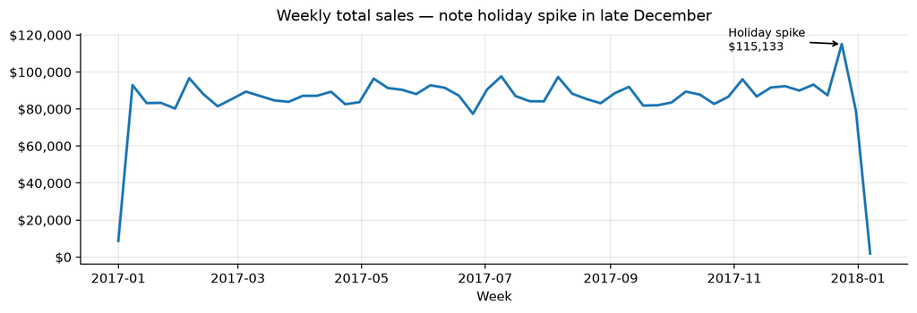

# Bokeh: Interactivity

## Bokeh — When Others Need to Explore

- Renders HTML/JavaScript — charts live in a **browser**, not just a notebook
- Users can **zoom, pan, hover, and filter** without writing new code
- Best for dashboards, stakeholder exploration tools, and shareable deliverables

Loading BokehJS ...

## Interactive Weekly Sales Explorer

```python
source = ColumnDataSource(weekly_sales)

p = figure(
    title='Total Weekly Sales — hover, zoom, and pan to explore',
    x_axis_type='datetime',
    width=750, height=350,
    tools='pan,wheel_zoom,box_zoom,reset,save'
)

p.line('week', 'total_sales', source=source,
       line_width=2, color='steelblue')

hover = HoverTool(tooltips=[
    ('Week',  '@week{%F}'),
    ('Sales', '@total_sales{$0,0}')
], formatters={'@week': 'datetime'})
p.add_tools(hover)

p.xaxis.axis_label = 'Week'
p.yaxis.axis_label = 'Total Sales ($)'

show(p)
```

**Tip**

Run this in the companion notebook to see the interactive version — it won’t fully render in a static slide.

**Exercise 1 — Run & Compare 💻**

Open the **Exercise 1** section of the companion notebook. Every cell is ready to run — **you don’t write any code today.**

Run them top to bottom. Same Complete Journey data, drawn four ways:

- **Pandas** — a one-line distribution, then a category comparison
- **Seaborn** — that same comparison, now split by group
- **Matplotlib** — the executive-ready version
- **Bokeh** — the interactive version

**Answer these two as you go:**

1. Which tool got to a usable chart with the **least code**?
2. Which output would you actually put in front of the CEO?

> 5 minutes — run, look, compare.

## Where You Actually Learn These 📚

Today was a **tour**. The readings are where you learn to drive.

| Chapter | What it teaches you | Where it shows up in the project |
| --- | --- | --- |
| **13** — Pandas | `.plot()` for fast exploratory charts | How you’ll explore your own data |
| **14** — Seaborn / Matplotlib / Bokeh | statistical charts, full control, interactivity | How you’ll build report-quality figures |
| **15** — EDA | a complete case study, start to finish | The model for your entire report |

**20 of the project’s 75 points ride on your charts**

**EDA (10 pts)** and **Findings (10 pts)** are graded on whether your visuals reveal something non-obvious *and* are clearly narrated. **Code & Craft** and **Delivery** lean on them too.

Nobody produces professional-looking figures on the first attempt. The reps come from working through these chapters and applying them to your own data.

# Part 2: How to Think About EDA

## You Already Have Most of What EDA Needs

| You learned | Which lets you |
| --- | --- |
| **Subsetting & filtering** (Wk 3) | isolate the rows a question is actually about |
| **`groupby` & aggregation** (Wk 4) | compute statistics at *any* level — household, basket, department, week |
| **Joins** (Wk 4) | pull in the context that makes a comparison possible |
| **Visualization** (this week) | see the shape, catch what’s wrong, show the finding |

Aggregation tells you **what the numbers are**. Visualization tells you **what they mean** and helps you **communicate them**. Together, that is most of an EDA.

**Important**

What’s left is understanding how to **ask a good question of our data**.

That’s what the rest of Part 2 is about.

## EDA Is a Conversation With Your Data

Exploratory Data Analysis is not a checklist of charts to run.

It is a **sequence of questions** — each answer raising the next question.

**Data dump (avoid)**

- Plot every variable
- Report every mean and median
- Move on

**Real EDA (aim for)**

- Start with a sharp question
- Let findings drive the next step
- Stop when you can tell a story

**Important**

The goal is not to show that you looked at the data. The goal is to find something worth saying.

## A Framework for EDA

```
flowchart LR
    A["1️⃣ Question"] --> B["2️⃣ Structure"]
    B --> C["3️⃣ Distributions"]
    C --> D["4️⃣ Segmentation"]
    D --> E["5️⃣ Story"]
    style A fill:#2c3e50,color:#fff
    style B fill:#2980b9,color:#fff
    style C fill:#27ae60,color:#fff
    style D fill:#e67e22,color:#fff
    style E fill:#8e44ad,color:#fff
```

| Step | Question to ask |
| --- | --- |
| **Question** | What do I actually want to know? Is it specific enough to know when I’ve answered it? |
| **Structure** | What shape is the data? What do I need to join? Where are the missing values? |
| **Distributions** | What does the outcome variable look like across all households? Any outliers? |
| **Segmentation** | Does the pattern differ across groups? Where does the interesting variation live? |
| **Story** | What changed? What surprised me? What should the decision-maker do next? |

## Step 1: Start With a Sharp Question

The question determines everything that follows.

**Caution**

**Too broad:** “How do customers shop?”

This can’t be answered — no unit of analysis, no metric, no comparison to make.

**Tip**

**Sharp:** “Do households that redeem coupons have larger basket spend than those that don’t — and does this differ across income brackets?”

This names: the unit (basket), the metric (spend), the comparison (coupon vs. no coupon), and the segmentation (income).

A sharp EDA question tells you which tables to join, which columns to compute, and what a result would look like.

**Note**

**We are going to answer this exact question** over the next four slides — one step of the framework at a time.

## Step 2: Structure — What Do I Actually Have?

Our question compares **baskets**, but `transactions` gives us 1.5 million *item* rows. So the first move is structural: collapse to **one row per basket**, flag which ones used a coupon, then attach household demographics for the income half of the question.

Every one of those steps can quietly lose rows — so count what survives:

```
Baskets:                    155,848
  ... that used a coupon:   9,827  (6.3%)
Households:                 2,469

After joining demographics: 81,817 baskets  (52% kept)
  ... households:           801
```

**Warning**

**The join cost us half the data.** Only 801 households have demographics. Any income comparison we make describes *those* households — not all shoppers. Notice this now, not in your conclusion.

## Step 3: Distributions — Which Summary Can I Trust?

Before comparing any groups, look at the outcome variable alone: **what does a typical basket even look like?**

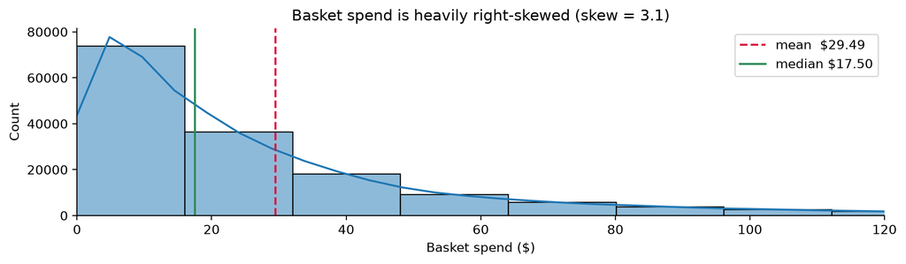

The mean sits **$12 above** the median — a handful of enormous baskets drag it to the right.

**Report the median — and say why you did**

With skew this strong, the **mean describes a basket almost nobody actually has**. The median is what a typical trip looks like, and it barely moves when a few $300 stock-ups show up.

Put that reasoning in your own report — one sentence is enough: *“We compare medians because basket spend is right-skewed.”* It tells your reader the choice was deliberate rather than a default, and defending a judgment call like this is exactly what the EDA portion of the rubric rewards.

## Step 4: Segmentation — Does the Pattern Hold?

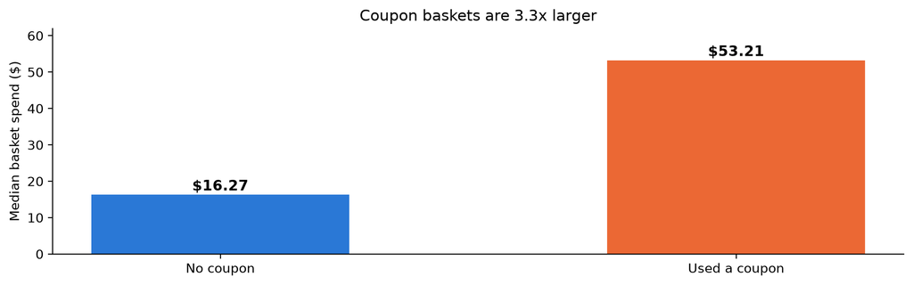

**And across income brackets?** The lift shows up in *every* bracket — 100% to 290%, with no clean upward or downward pattern.

**Note**

Let’s look, rather than assert.

## Step 4 (cont.): Does It Differ by Income?

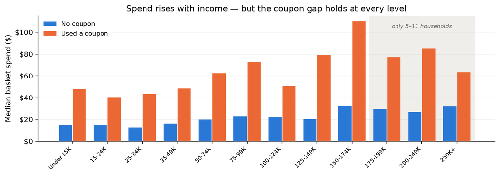

Orange clears blue in **every single bracket**. Both series drift up with income — so the real question is whether the *gap* widens.

**Note**

It doesn’t. As a ratio the lift bounces from **roughly 100% up to 290%** with no clean direction. Richer households spend more per trip, coupon or not — but **the coupon effect itself is not an income story.** The second half of our question resolves to “no,” and ruling something out is progress, not failure.

**Warning**

And notice the shaded brackets: those medians rest on **5–11 households**. That is the Step 2 join loss surfacing exactly where you’d be most tempted to read a trend.

## Step 5: Build the Story — and the “So What” Test

A 3.3x gap is tempting. **Push one question further before you recommend anything.**

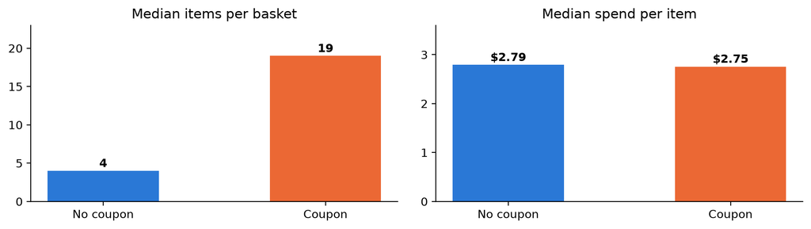

**Spend per item is identical.** Coupon baskets are not *pricier* — they are simply **bigger trips**.

## What We Can — and Cannot — Say

**The “So What” Test**

*So what?* Coupon redemption marks the **weekly stock-up trip**, not a change in what people buy.

**Caution**

**The recommendation we cannot make:** *“Send more coupons to grow basket size.”*

Nothing here shows coupons **caused** bigger baskets. Shoppers planning a big trip may be the ones who bother to bring a coupon.

**Next question:** do the *same* households shop differently with and without a coupon? That comparison could support a causal claim. This one can’t.

**Exercise 2 — What’s the Next Question? 🤔**

We concluded: *coupon baskets are 3.3x larger, but spend per item is identical — coupons mark stock-up trips.*

Your VP of Promotions reads this and asks: **“So should we mail more coupons?”**

Name **3 follow-up analyses** you would run before answering, and what each would tell you.

> Discuss with your neighbor for 3 minutes.

# Part 3: The Semester Project

## The Regork Scenario

You are a data scientist at **Regork**, a national grocery chain.

Your manager has asked you to identify a **potential growth opportunity** — an area where the company could invest future resources to increase revenue or profits.

Your task:

1. Define a **clear business question** that investigates a specific growth opportunity
2. Analyze the Complete Journey data to answer it
3. Communicate your findings through:
   - A **written analytic report** (Jupyter Notebook → HTML)
   - A **3-minute recorded presentation** for the CEO

**Tip**

**Groups:** 2–4 students. Sign up in Canvas → People → Project Groups.

## What a Sharp Business Question Looks Like

**You just watched one get answered**

*“Do households that redeem coupons have larger basket spend than those that don’t — and does this differ across income brackets?”*

That question survived contact with the data because it named four things up front:

| It named | Which told us |
| --- | --- |
| A **unit** — the basket | what one row of our table had to be |
| A **metric** — spend | what to compute, and that skew mattered |
| A **comparison** — coupon vs. not | what the chart at Step 4 had to show |
| A **segmentation** — income | what to check next, even though it came back empty |

Notice it was answerable in **four steps** — and we knew we were done. That is the bar.

## Three More Sharp Questions

**Private label**

*“Do households with kids buy a higher share of private-label products than households without — and does that gap differ by department?”*

Unit: household · Metric: private-label share of spend · Compare: kids vs. none · Segment: department

**Trip behavior**

*“Do households that shop twice a week or more spend more over the year than occasional shoppers — or do they spread the same annual spend across more trips?”*

Unit: household · Metric: annual spend & trip count · Compare: frequent vs. occasional · Segment: income

**Promotions**

*“Do products featured in the weekly mailer sell more during the featured week — and does any lift carry into the week after?”*

Unit: product-week · Metric: units sold · Compare: featured vs. not · Segment: department

**Note**

Notice the second one has the **same shape as our coupon finding**: *“more spend”* and *“more trips”* are different answers, and the question is built so you can tell them apart. Design that distinction in from the start — don’t discover it at the end.

## What Strong Analysis Looks Like

**A question worth asking** — specific, answerable, and tied to a decision someone actually makes. You saw the standard in Part 2.

**A named decision-maker** — who acts on this, and what do they do differently on Monday? The VP of Promotions needs a recommendation, not a summary of what you computed.

**Reasoning you can follow** — structure, then distributions, then segmentation. Each step raises the next question. Show the reasoning, not just the outputs.

**Honesty about limits** — say what your analysis does *not* establish. The strongest projects name the recommendation they can’t yet make, and what would be needed to make it.

**Tip**

Every chart earns its place by making **one** point. Label the axes, use a readable scale, and narrate what the reader should see. Plots without interpretation are decoration.

**Don’t guess at the bar — go look at it**

The Canvas project page includes **real report and presentation submissions from previous classes.** They are the clearest picture you will get of what “strong” actually means.

Before you write anything, read two of them end to end and ask: *what did they investigate, how did they narrate each chart, and where did they choose to stop?* An hour spent there will do more for your grade than an extra hour of code.

## Deliverables

### A. Written Technical Report

- Jupyter Notebook rendered to **HTML**
- Must include: data preparation, business question, EDA, narrative findings, recommendations
- Show relevant code; suppress warnings and unnecessary/distracting output
- File naming: `YYYY_BANA7025_groupXX_project.html`

### B. Recorded Stakeholder Presentation

- **3 minutes maximum** — no code, executive audience
- Covers: business problem, key findings, one clear recommendation
- Recorded via Zoom or Kaltura and submitted through Canvas

**Note**

One group member submits both deliverables together. Submit early — large video files can take time to upload.

## What Gets Graded — and Where to Find the Rubric

**75 points total:** written report (40) + recorded presentation (35).

**Report — 40 pts**

| Section | Pts |
| --- | --- |
| Introduction | 5 |
| Libraries | 5 |
| EDA | 10 |
| Summary | 5 |
| Code & Craft | 15 |

**Presentation — 35 pts**

| Section | Pts |
| --- | --- |
| Introduction | 5 |
| Findings | 10 |
| Summary | 5 |
| Delivery | 15 |

**Canvas → Assignments → Project**

Full description, the **complete rubric**, and **example submissions from a previous course**. Reading the rubric *before* you start is one of the highest-leverage things you can do.

**Tip**

EDA (10 pts) is where projects separate. One non-obvious pattern explained well beats five polished charts that say nothing new.

## Thursday’s Lab: Project Ideation

In Thursday’s lab you will:

1. Form your group (2–4 students) and join a Canvas group
2. **Brainstorm three distinct project ideas**, each with a business problem, decision-maker, data plan, and success criteria
3. Choose your most compelling idea and do a **2–3 minute stand-up pitch** to the class

**Tips for a Strong Pitch**

- Lead with the **question**, not the dataset
- Name a **specific decision-maker** and what they would do with your findings
- Describe **what a meaningful finding would look like** — not just “explore the data”

**After lab:** refine your idea into a formal proposal (the homework due this week).

## Q&A 🙋

Open floor for questions on:

- Today’s visualization tools or the exercise
- The EDA framework and how it connects to the project
- Project scope, deliverables, or the proposal
- Anything from the reading or labs so far